# Simulating a clinical trial dataset with missing values

Author

Laura Symul, Aurélie Bertrand, & Claude AI

Published

November 27, 2026

## Overview

This document simulates a clinical trial dataset with missing values.

The dataset contains participant-level information, including study design data (study site, randomization arm), some demographic and anthropometric variables (sex, age, height, weight), lifestyle factors (physical activity), and the clinical outcome (cure).

Specifically, it creates the two datasets used in the `mice` demo (`04_mice_demo.qmd`):

1. **`data_complete`**: a synthetic randomised trial with no missing values, including the participants’ BMI (`bmi`).
2. **`data_missing`**: a copy of `data_complete` with `bmi` removed and missing values introduced under a **missing at random (MAR)** mechanism.

Both datasets are saved as `.RData` files.

```r
library(tidyverse)
library(gt)
library(glue)
theme_set(theme_light())

n <- 200 # number of participants
set.seed(999)
```

## Part 1: The complete dataset

### Data-generating process

```r
sim_pars <-
  list(
    study_sites = c("A", "B", "C"),
    sex = c("F", "M"),
    age_range = c(18, 80),
    ht_mean = c(F = 166, M = 180),
    ht_sd = 7,
    ht_decline_age = 60,
    ht_decline_per_year = 0.1,
    physical_activity_levels = c("low", "med", "high"),
    physical_activity_probs = c(0.35, 0.40, 0.25),
    physical_activity_probs_site_A = c(0.15, 0.35, 0.50),
    physical_activity_probs_site_C = c(0.6, 0.25, 0.15),
    bmi_median = c(low = 30, med = 24, high = 18),
    bmi_sd_log = 0.05
  )
```

We simulate the variables one after the other, so that each one can depend on the ones simulated before it.

```r
sim_tbl <- tribble(
  ~Variable             , ~`Simulation specifications`                                                                                                                                                                                                                                       ,
  "`study_site`"        , glue('{toString(sim_pars$study_sites)} with equal probability')                                                                                                                                                                                                    ,
  "`arm`"               , '1:1 randomisation to `"placebo"` or `"treatment"`'                                                                                                                                                                                                                ,
  "`sex`"               , '`"F"` or `"M"` with probability 0.5 each'                                                                                                                                                                                                                         ,
  "`age`"               , glue("Uniform between {sim_pars$age_range[1]} and {sim_pars$age_range[2]} years (whole years)")                                                                                                                                                                    ,
  "`ht`"                , glue("Normal, mean {sim_pars$ht_mean['M']} cm (M) or {sim_pars$ht_mean['F']} cm (F), ", "SD {sim_pars$ht_sd} cm, with a {sim_pars$ht_decline_per_year} cm/year decline ", "after age {sim_pars$ht_decline_age}")                                                   ,
  "`physical_activity`" , glue('`"low"`, `"med"`, `"high"` with probabilities ', '{toString(sim_pars$physical_activity_probs_site_A)} at site `"A"`, ', '{toString(sim_pars$physical_activity_probs_site_C)} at site `"C"`, ', 'and {toString(sim_pars$physical_activity_probs)} otherwise') ,
  "`bmi`"               , glue("Log-normal distribution depending on physical activity level, with median ", "{sim_pars$bmi_median['low']} (low), {sim_pars$bmi_median['med']} (med) or ", "{sim_pars$bmi_median['high']} (high) kg/m², and SD {sim_pars$bmi_sd_log} on the log scale")      ,
  "`wt`"                , "bmi × (ht / 100)², in kg"                                                                                                                                                                                                                                         ,
  "`cure`"              , "Bernoulli, with the probability given by the logistic model below"
)


sim_tbl |>
  gt() |>
  fmt_markdown(columns = everything()) |>
  cols_align(align = "left", columns = everything()) |>
  tab_style(
    style = cell_borders(sides = "bottom", weight = px(1), color = "black"),
    locations = cells_body(rows = c(2, 8))
  )
```

| Variable | Simulation specifications |
| --- | --- |
| `study_site` | A, B, C with equal probability |
| `arm` | 1:1 randomisation to `"placebo"` or `"treatment"` |
| `sex` | `"F"` or `"M"` with probability 0.5 each |
| `age` | Uniform between 18 and 80 years (whole years) |
| `ht` | Normal, mean 180 cm (M) or 166 cm (F), SD 7 cm, with a 0.1 cm/year decline after age 60 |
| `physical_activity` | `"low"`, `"med"`, `"high"` with probabilities 0.15, 0.35, 0.5 at site `"A"`, 0.6, 0.25, 0.15 at site `"C"`, and 0.35, 0.4, 0.25 otherwise |
| `bmi` | Log-normal distribution depending on physical activity level, with median 30 (low), 24 (med) or 18 (high) kg/m², and SD 0.05 on the log scale |
| `wt` | bmi × (ht / 100)², in kg |
| `cure` | Bernoulli, with the probability given by the logistic model below |

The probability of cure follows a logistic model:

$$\text{logit}\, P(\text{cure} = 1) = \beta_0 + \beta_\text{trt}\, \text{trt} + \beta_\text{wt}\, (\text{wt} - 80)\, \text{trt} - \beta_{\text{age}} \, (\text{age} - 50)$$

where “trt” is 1 for participants in the treatment arm.

```r
beta_0 <- qlogis(0.30) # placebo, BMI = 26
beta_trt <- log(2.5) # treatment effect
beta_wt <- log(0.95) # per weight unit
beta_age <- 0.1 # per year of age
```

### Simulation

```r
data_complete <-
  tibble(id = sprintf("P%03d", 1:n)) |>
  mutate(
    study_site = sample(sim_pars$study_sites, n, replace = TRUE) |> factor(),
    sex = sample(sim_pars$sex, n, replace = TRUE) |>
      factor(levels = sim_pars$sex),
    age = round(runif(
      n,
      min = sim_pars$age_range[1],
      max = sim_pars$age_range[2]
    )),
    ht = rnorm(
      n,
      mean = if_else(sex == "M", sim_pars$ht_mean["M"], sim_pars$ht_mean["F"]) -
        sim_pars$ht_decline_per_year * pmax(age - sim_pars$ht_decline_age, 0),
      sd = 7
    ),
    physical_activity = {
      pa <- character(n)
      site_a <- study_site == "A"
      site_c <- study_site == "C"
      pa[site_a] <- sample(
        sim_pars$physical_activity_levels,
        sum(site_a),
        replace = TRUE,
        prob = sim_pars$physical_activity_probs_site_A
      )
      pa[site_c] <- sample(
        sim_pars$physical_activity_levels,
        sum(site_c),
        replace = TRUE,
        prob = sim_pars$physical_activity_probs_site_C
      )
      pa[!(site_a | site_c)] <- sample(
        sim_pars$physical_activity_levels,
        sum(!(site_a | site_c)),
        replace = TRUE,
        prob = sim_pars$physical_activity_probs
      )
      factor(pa, levels = sim_pars$physical_activity_levels)
    },
    bmi = exp(rnorm(
      n,
      mean = log(case_match(
        physical_activity,
        "low" ~ sim_pars$bmi_median["low"],
        "med" ~ sim_pars$bmi_median["med"],
        "high" ~ sim_pars$bmi_median["high"]
      )),
      sd = sim_pars$bmi_sd_log
    )),
    wt = bmi * (ht / 100)^2,
    arm = sample(rep(c("placebo", "treatment"), length.out = n)) |>
      factor(levels = c("placebo", "treatment")),
    p_cure = plogis(
      beta_0 +
        beta_trt * (arm == "treatment") +
        beta_wt * (wt - 80) * (arm == "treatment") -
        0.1 * (age - 50)
    ),
    cure = rbinom(n, size = 1, prob = p_cure)
  ) |>
  mutate(across(c(ht, wt, bmi), \(x) round(x, 1))) |>
  select(id, study_site, sex, age, ht, wt, bmi, physical_activity, arm, cure)

data_complete
```

```
# A tibble: 200 × 10
   id    study_site sex     age    ht    wt   bmi physical_activity arm     cure
   <chr> <fct>      <fct> <dbl> <dbl> <dbl> <dbl> <fct>             <fct>  <int>
 1 P001  C          F        71  171.  93.2  32   low               treat…     0
 2 P002  B          M        66  175.  45.9  15   high              place…     0
 3 P003  A          F        40  151.  50.5  22.3 med               treat…     1
 4 P004  B          F        31  168.  68.3  24.3 med               treat…     1
 5 P005  A          M        50  179.  90.6  28.2 low               place…     0
 6 P006  A          M        19  171.  54.8  18.7 high              place…     1
 7 P007  B          F        46  153.  58.2  24.8 med               place…     1
 8 P008  A          M        52  183.  81.2  24.2 med               treat…     1
 9 P009  C          F        23  168.  81.6  28.9 low               place…     1
10 P010  B          M        70  173.  88.7  29.6 low               treat…     0
# ℹ 190 more rows
```

### Summary and visualization of simulated data

```r
data_complete |>
  group_by(sex) |>
  summarise(
    n = n(),
    across(c(age, ht, wt, bmi), \(x) round(mean(x), 1), .names = "mean_{.col}")
  ) |>
  gt()
```

| sex | n | mean_age | mean_ht | mean_wt | mean_bmi |
| --- | --- | --- | --- | --- | --- |
| F | 105 | 48.0 | 165.9 | 68.0 | 24.6 |
| M | 95 | 53.1 | 178.6 | 77.5 | 24.3 |

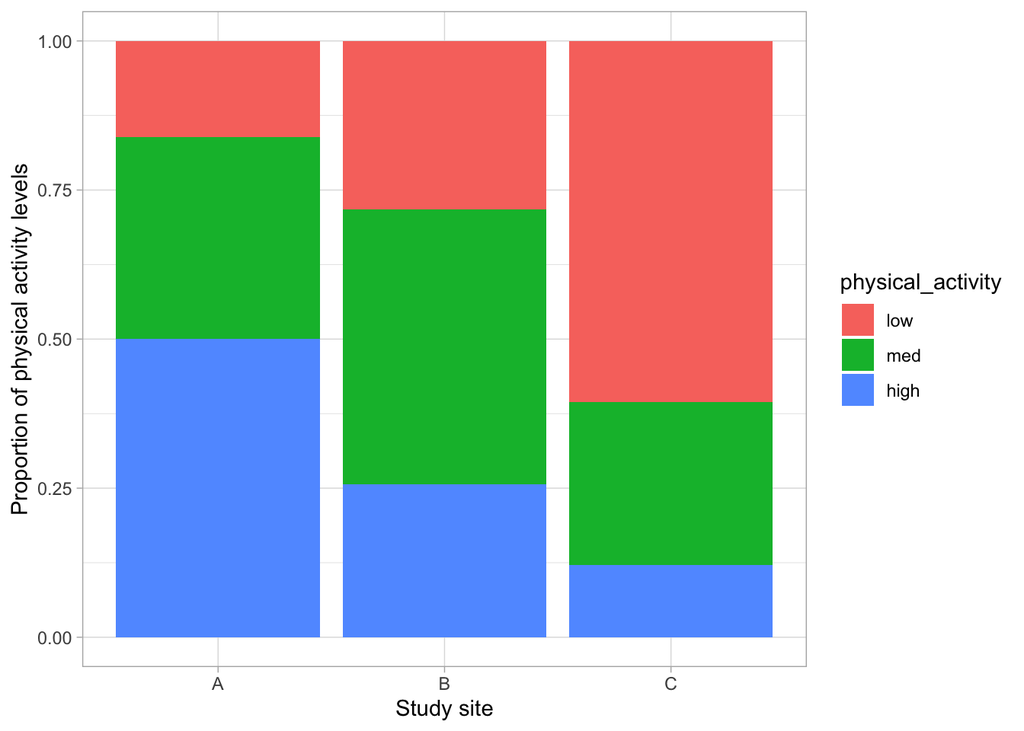

Figure 1: Physical activity by study site.

```r
data_complete |>
  ggplot(aes(x = study_site, fill = physical_activity)) +
  geom_bar(position = "fill") +
  labs(x = "Study site", y = "Proportion of physical activity levels")
```

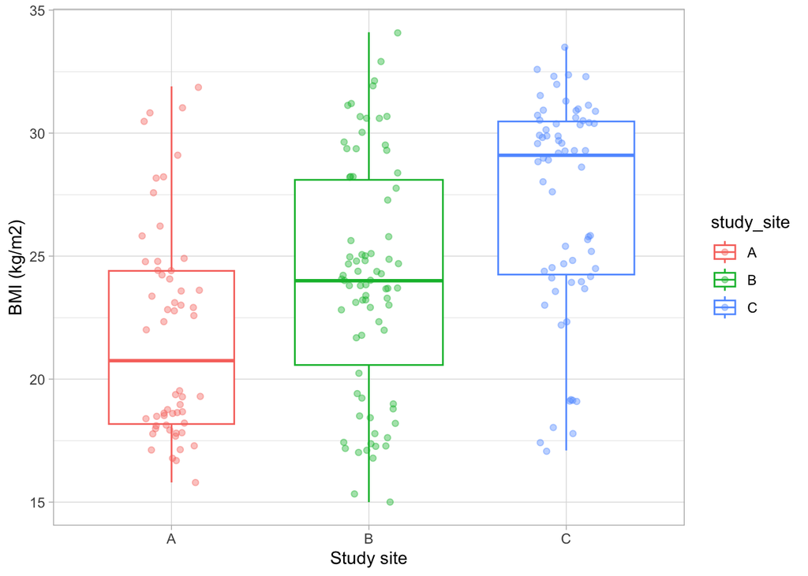

Figure 2: BMI by study site.

```r
data_complete |>
  ggplot(aes(x = study_site, y = bmi, col = study_site)) +
  geom_boxplot(outlier.shape = NA, varwidth = TRUE) +
  geom_jitter(width = 0.15, alpha = 0.4) +
  labs(x = "Study site", y = "BMI (kg/m2)")
```

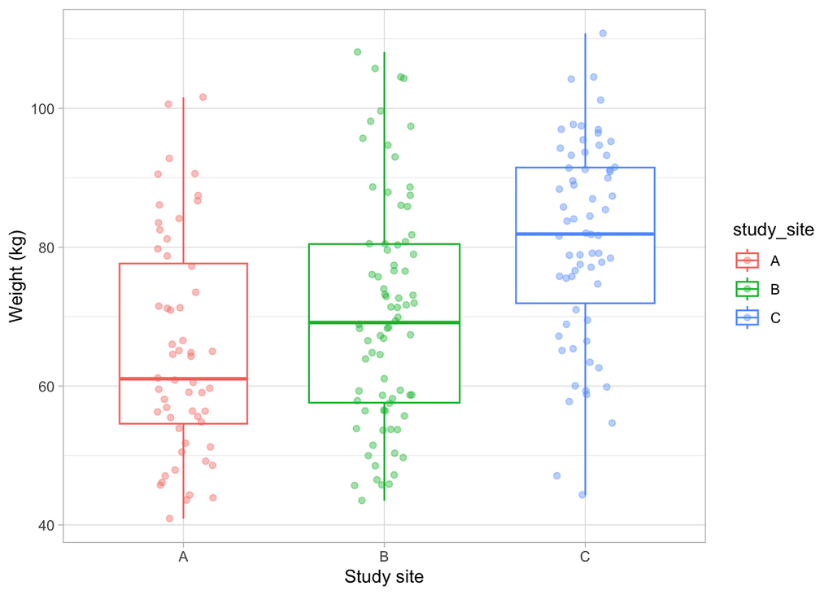

Figure 3: Weight by study site.

```r
data_complete |>
  ggplot(aes(x = study_site, y = wt, col = study_site)) +
  geom_boxplot(outlier.shape = NA, varwidth = TRUE) +
  geom_jitter(width = 0.15, alpha = 0.4) +
  labs(x = "Study site", y = "Weight (kg)")
```

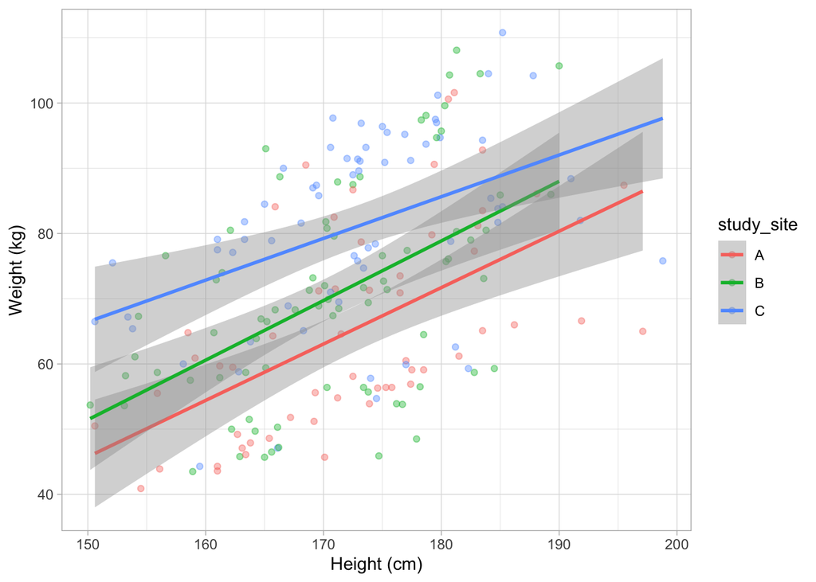

Figure 4: Weight versus height by study site.

```r
data_complete |>
  ggplot(aes(x = ht, y = wt, col = study_site)) +
  geom_point(width = 0.15, alpha = 0.4) +
  geom_smooth(method = "lm") +
  labs(x = "Height (cm)", y = "Weight (kg)")
```

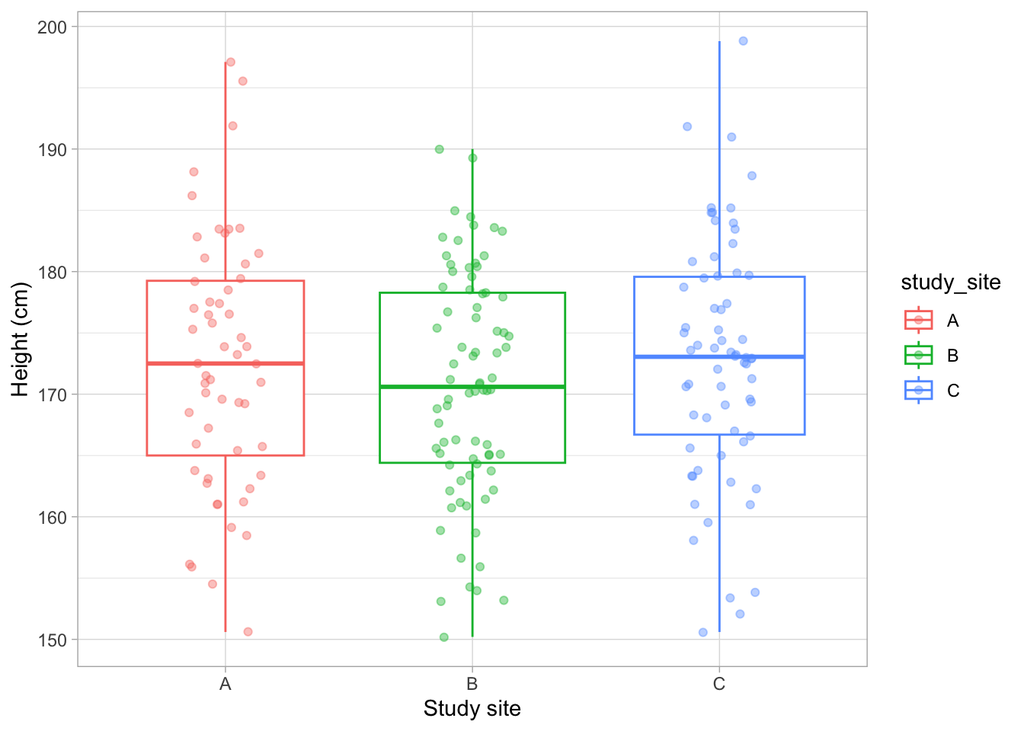

Figure 5: Height by study site.

```r
data_complete |>
  ggplot(aes(x = study_site, y = ht, col = study_site)) +
  geom_boxplot(outlier.shape = NA, varwidth = TRUE) +
  geom_jitter(width = 0.15, alpha = 0.4) +
  labs(x = "Study site", y = "Height (cm)")
```

```r
data_complete |>
  group_by(arm, sex) |>
  summarise(n = n(), cure_rate = mean(cure), .groups = "drop") |>
  gt()
```

| arm | sex | n | cure_rate |
| --- | --- | --- | --- |
| placebo | F | 51 | 0.4117647 |
| placebo | M | 49 | 0.3061224 |
| treatment | F | 54 | 0.6111111 |
| treatment | M | 46 | 0.5217391 |

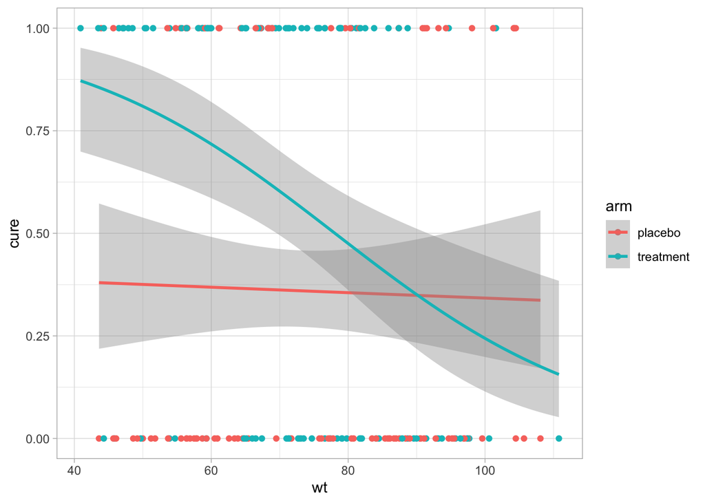

```r
data_complete |>
  ggplot() +
  aes(x = wt, y = cure, col = arm) +
  geom_point() +
  geom_smooth(
    method = "glm",
    method.args = list(family = "binomial")
  )
```

## Part 2: The dataset with missing values

### Missingness mechanism

We remove `bmi` (it is typically a “calculated variable” and not a raw measurement) and introduce missing values as follows:

- **Study site**: at sites A and B, the baseline probability that `age`, `ht`, `wt` or `physical_activity` is missing is 10%. At site C it is 30%.
- **wt**: is more likely to be missing than the other variables and probability also depends on the study site
- Study design and outcome variables (`id`, `study_site`, `arm` and `cure`) are never missing.

Because missingness depends only on the study site (which is always observed), the data are **missing at random (MAR)**.

```r
p_miss_site <- c(A = 0.10, B = 0.10, C = 0.30)
p_miss_wt <- c(A = 0.1, B = 0.1, C = 0.9)
```

```r
# Draw one missingness indicator per participant and variable
add_missing <- function(x, p) if_else(runif(length(x)) < p, NA, x)

data_missing <-
  data_complete |>
  select(-bmi) |>
  mutate(
    # Probability of missingness based on study site and variable-specific effect for wt
    p_miss = p_miss_site[as.character(study_site)],
    across(c(age, ht, physical_activity), \(x) add_missing(x, p_miss)),
    wt = add_missing(wt, p_miss_wt[as.character(study_site)]),
  ) |>
  select(-p_miss)


data_missing |>
  head(10) |>
  gt(caption = "First 10 rows of the dataset with missing values") |>
  # highlight missing values by coloring them
  tab_style(
    style = cell_fill(color = "lightpink"),
    locations = map(
      colnames(data_missing),
      \(col) cells_body(columns = all_of(col), rows = is.na(.data[[col]]))
    )
  )
```

First 10 rows of the dataset with missing values

| id | study_site | sex | age | ht | wt | physical_activity | arm | cure |
| --- | --- | --- | --- | --- | --- | --- | --- | --- |
| P001 | C | F | NA | NA | NA | low | treatment | 0 |
| P002 | B | M | 66 | 174.7 | 45.9 | high | placebo | 0 |
| P003 | A | F | 40 | 150.6 | NA | med | treatment | 1 |
| P004 | B | F | 31 | 167.6 | 68.3 | med | treatment | 1 |
| P005 | A | M | 50 | 179.4 | 90.6 | low | placebo | 0 |
| P006 | A | M | 19 | 171.2 | NA | NA | placebo | 1 |
| P007 | B | F | 46 | 153.2 | 58.2 | med | placebo | 1 |
| P008 | A | M | 52 | 183.1 | 81.2 | med | treatment | 1 |
| P009 | C | F | 23 | NA | NA | NA | placebo | 1 |
| P010 | B | M | 70 | 173.1 | 88.7 | NA | treatment | 0 |

### Checks

Proportion of missing values per variable:

```r
data_missing |>
  summarise(across(everything(), \(x) mean(is.na(x)))) |>
  pivot_longer(everything(), names_to = "variable", values_to = "prop_missing")
```

```
# A tibble: 9 × 2
  variable          prop_missing
  <chr>                    <dbl>
1 id                       0
2 study_site               0
3 sex                      0
4 age                      0.155
5 ht                       0.15
6 wt                       0.39
7 physical_activity        0.165
8 arm                      0
9 cure                     0
```

Proportion of missing values per variable and study site:

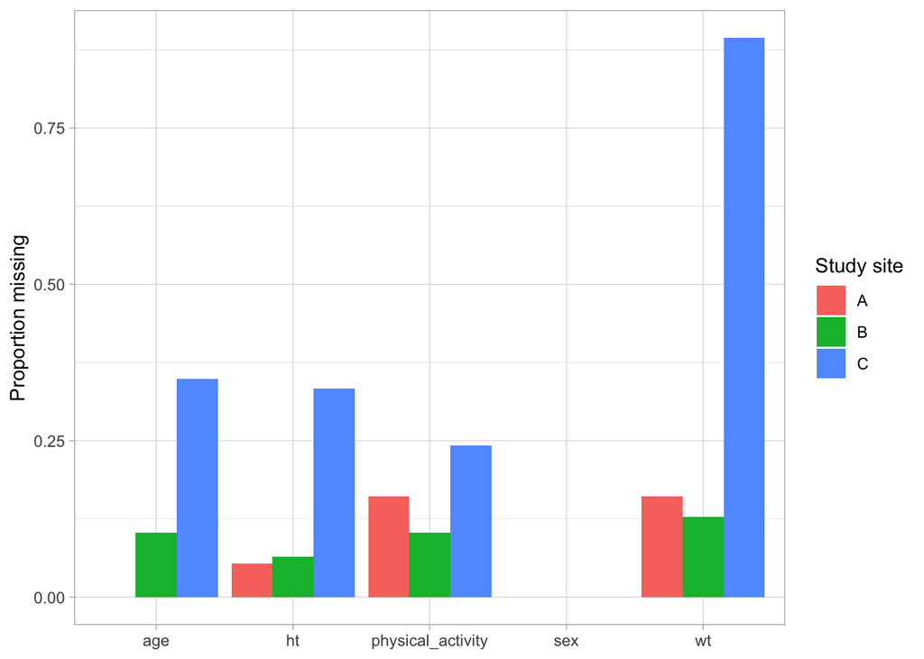

Figure 6: Proportion of missing values by study site.

```r
data_missing |>
  pivot_longer(
    c(sex, age, ht, wt, physical_activity),
    names_to = "variable",
    values_transform = as.character
  ) |>
  group_by(study_site, variable) |>
  summarise(prop_missing = mean(is.na(value)), .groups = "drop") |>
  ggplot(aes(x = variable, y = prop_missing, fill = study_site)) +
  geom_col(position = "dodge") +
  labs(x = NULL, y = "Proportion missing", fill = "Study site")
```

Number of missing values per participant:

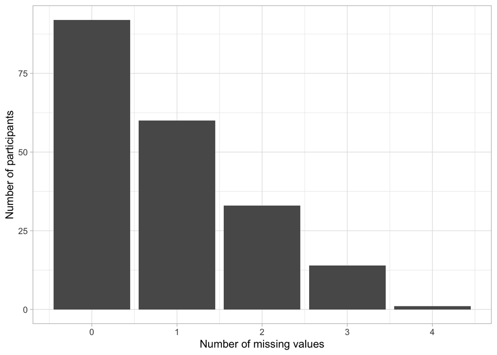

Figure 7: Number of missing values per participant.

```r
data_missing |>
  mutate(n_missing = rowSums(is.na(pick(everything())))) |>
  count(n_missing) |>
  ggplot(aes(x = n_missing, y = n)) +
  geom_col() +
  labs(x = "Number of missing values", y = "Number of participants")
```

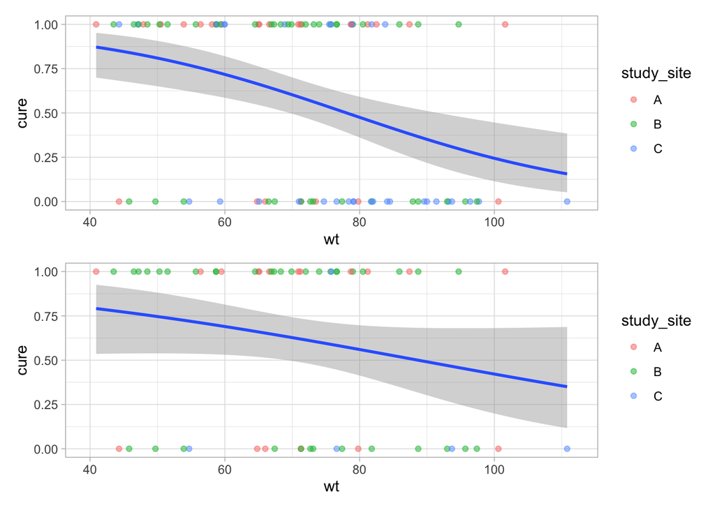

Figure 8: Scatter plots of weight vs cure for complete and missing data.

```r
library(patchwork)
data_complete |>
  filter(arm == "treatment") |>
  ggplot() +
  aes(x = wt, y = cure) +
  geom_point(alpha = 0.5, aes(col = study_site)) +
  geom_smooth(method = "glm", method.args = list(family = "binomial")) +
  xlim(range(data_complete$wt) + c(-1, 1)) +

  data_missing |>
    filter(arm == "treatment") |>
    ggplot() +
  aes(x = wt, y = cure) +
  geom_point(alpha = 0.5, aes(col = study_site)) +
  geom_smooth(method = "glm", method.args = list(family = "binomial")) +
  xlim(range(data_complete$wt) + c(-1, 1)) +

  plot_layout(ncol = 1)
```

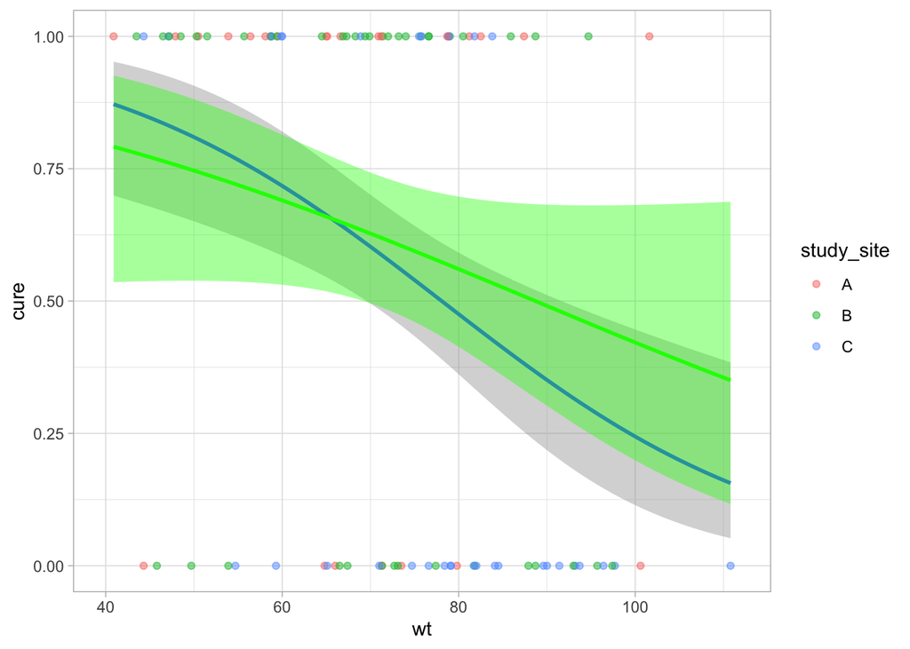

Figure 9: Scatter plot of weight vs cure for complete and missing data (in green).

```r
data_complete |>
  filter(arm == "treatment") |>
  ggplot() +
  aes(x = wt, y = cure) +
  geom_point(alpha = 0.5, aes(col = study_site)) +
  geom_smooth(method = "glm", method.args = list(family = "binomial")) +
  geom_smooth(
    data = data_missing |> filter(arm == "treatment"),
    method = "glm",
    method.args = list(family = "binomial"),
    col = "green",
    fill = "green"
  ) +
  xlim(range(data_complete$wt) + c(-1, 1))
```

## Export & Session info

```r
save(data_complete, file = "simulated_data/data_complete.RData")
save(data_missing, file = "simulated_data/data_missing.RData")
```

The files `data_complete.RData` and `data_missing.RData` are saved in the `simulated_data/` directory.